# Setting up environments on your laptop

# (general and deep learning example)

**Authors:** Gena Gibson

## Intro

This file contains instructions to set up environments that you can use with your python coding.

### Why do we need environments?

Since python libraries are constantly evolving, using different versions can break other packages

- Environments keep packages/language version separate
- Environments mean that packages you install for one project don't break the packages you have for another project
- They mean that your colleagues can run the same code without errors - important for reproducible results on different machines!!
- Ideally, try to create a new environment for each project

A specific example is give for deep learning, since there are difficult dependencies that can lead to problems. It may take you hours to find a solution by installing individual packages: using this tutorial should have you set up in minutes. You need specific versions of python for our preferred deep learning libraries (Tensorflow and Keras) to work properly.

There are also other environments available to set up a consistent set of packages for other projects - see the repository.

**Before you start, check that you have the latest version of this guidance:**  
Go to the GitHub repository: https://github.com/genagibson/ricardo_template_style  
Download the repository as a zip file, or clone it if you know how to use Git.

## Available Ricardo environments (a growing list)

- `ricardo_general`: this contains most of the libraries that you are likely to need for general purpose projects, including plotting, interactive plotting, numerical analysis and machine learning
- `ricardo_deep_learning`: contains specialised libraries for deep learning that require a specific setup
- Others may be added

## Setup

- Open anaconda prompt (Windows) or a terminal (Mac)
- Type `conda -v`
- If you get an error, install Anaconda. See instructions in 00_Setup.html
- If there is no error, type `conda update conda` to make sure you have the latest version
- Find the yml files in this repository:

  https://github.com/genagibson/ricardo_template_style/

  ```
    ricardo_environments/
        ricardo_deep_learning.yml
        ricardo_general.yml
        ... others may be added
  ```

- Clone the repository into Git (if you are using proper version control - highly recommended you do it this way!)
  - Otherwise, copy the repository to somewhere on your desktop
- Find the path to the yml files: Mine is: Documents/GitHub/ricardo_template_styles/ricardo_environments
- Run the following command to create the environments
  - Windows: `conda env create -f [PATH]\ricardo_deep_learning.yml`
  - Mac: `conda env create -f [PATH]/ricardo_deep_learning.yml`

Or whichever yml file you are using.

Setup may take a few minutes while all of the packages are installed, and several printouts will appear. It should look roughly like this:

Creation of the environment

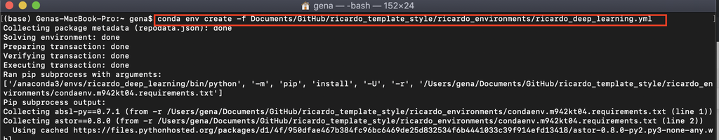

**NB:** This example creates an environment for deep learning, but the same steps can be used for any environment:  
Just change the *.yml to the one you want.

### What is it doing?

While we wait, let's go over what is happening. The yml file (or yaml) is creating a separate set of python packages in a specific environment called ricardo_deep_learning. This means that anything you install in other environments won't interfere with or break the work you're doing in this environment.

Conda is a tool that manages these environments for us.

## How to use the environment (deep learning example)

You only need to create the environment once. In order to work inside the environment, you need to activate it each time you start a new session:

1. Activate the environment:
   - Windows: in anaconda prompt type `conda activate ricardo_deep_learning`
   - Mac: in terminal, type `source activate ricardo_deep_learning`
2. Launch Jupyter as normal by typing `jupyter notebook`
3. When you're finished, deactivate the environment
   - Windows: conda deactivate
   - Mac: source deactivate

When the environment is working, you can see that your base will change to (ricardo_deep_learning).

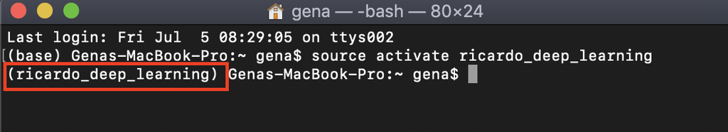

This environment set-up has been tested to work with rather complicated neural nets, so you should be fine to do whatever you want. To test if it's working, launch a Jupyter Notebook from the activated environment and type in:

[output not shown]

If you get an output like the one below, it should be working.

Test it is working

[figure not shown]

By the way, you might get some warnings about depreciations - as mentioned, the libraries are constantly being upgraded and things are depreciated. Usually the warnings don't mean anything has broken.

## Managing packages

### Installing new packages into the environment

You'll notice that the environment only has the packages that were explicitly included in the yml file. I added the main libraries that are likely to be important.

You can always install packages within this new environment by using `pip install [package]`. However, remember that this means that other people using the same environment won't have access to that package.

For full reproducibility, you should create a new .yml file for your project, then share it with the team.

### Check your list of environments

If you're following the advice from earlier, you'll end up with a big list of environments. You can always check what they are by running:

```
conda info --envs
```

### Sharing environments

You may want to share your environment with someone else---for example, so they can re-create a test that you have done. To allow them to quickly reproduce your environment, with all of its packages and versions, give them a copy of your environment.yml file. Just like we've done here. The conda documentation is very good: https://docs.conda.io/projects/conda/en/latest/user-guide/tasks/manage-environments.html#sharing-an-environment

Contact gena.gibson@ricardo.com for suggestions  
Version last updated on 05 July 2019